# Basic package description

To limit this documentation size, most figures are not displayed in the version of the vignette included in the package. To see all figures, you can rerun the vignettes, changing the following option to `TRUE`:

```r
knitr::opts_chunk$set(include = FALSE)
```

Alternatively, this compilation is also available at: http://sombrero.nathalievialaneix.eu/articles/c-doc-numericSOM.html

## Basic package description

`SOMbrero` implements different variants of the Self-Organizing Map algorithm (also called Kohonen's algorithm). To run the standard version of the algorithm, use the function `trainSOM()` on a data frame or matrix with numerical columns. The standard numeric SOM and its use in `SOMbrero` are illustrated below.

**This documentation only considers the case of numerical data.**

### Arguments

The `trainSOM` function has several arguments, but only the first one is required. This argument is `x.data` which is the dataset used to train the SOM. In this documentation, it is passed to the function as a matrix or a data frame with numerical variables in columns and observations of these variables in rows.

The other arguments are the same as the arguments passed to the `initSOM` function (they are parameters defining the algorithm, see `help(initSOM)` for further details).

### Outputs

The `trainSOM` function returns an object of class `somRes` (see `help(trainSOM)` for further details on this class).

### Graphics

The following table indicates which graphics are available for a numeric SOM.

| What SOM or SC Type | SOM Energy | Obs | Prototypes | Add | SuperCluster (no what) | Obs | Prototypes | Add |
| --- | --- | --- | --- | --- | --- | --- | --- | --- |
| (no type) | x |  |  |  |  |  |  |  |
| hitmap |  | x |  |  |  | x |  |  |
| color |  | x | x | x |  | x | x |  |
| lines |  | x | x | x |  | x | x | x |
| meanline |  | x |  | x |  | x |  | x |
| barplot |  | x | x | x |  | x | x | x |
| pie |  |  |  | x |  |  |  | x |
| boxplot |  | x |  | x |  | x |  | x |
| 3d |  |  | x |  |  |  |  |  |
| poly.dist |  |  | x |  |  |  | x |  |
| umatrix |  |  | x |  |  |  |  |  |
| smooth.dist |  |  | x |  |  |  |  |  |
| mds |  |  | x |  |  |  | x |  |
| grid.dist |  |  | x |  |  |  |  |  |
| words |  |  |  | x |  |  |  |  |
| names |  | x |  | x |  |  |  |  |
| grid |  |  |  |  |  |  | x |  |
| dendrogram |  |  |  |  | x |  |  |  |
| dendro3d |  |  |  |  | x |  |  |  |

## First case study: simulated data in \([0,1]^2\)

### Training the SOM

The energy evolves as described in the following graphic:

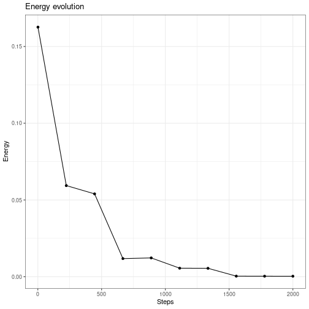

```r
plot(my.som, what="energy")
```

### Clustering

The observations are almost uniformly distributed on the map.

The clustering component allows us to plot the initial data according to the final clustering.

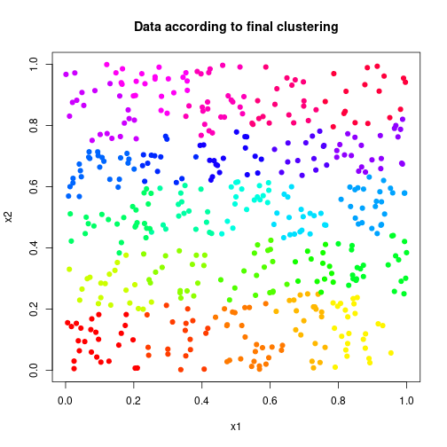

```r
# prepare a vector of colors
my.colors <- rainbow(prod(my.som$parameters$the.grid$dim))[my.som$clustering]

# points depicted with the same color are in the same final cluster
plot(my.som$data[,1], my.som$data[,2], col=my.colors, pch=19, xlab="x1",
     ylab="x2", main="Data according to final clustering")
```

### Clustering interpretation

The values of the prototypes can be represented with the plot function and help interpret the clusters:

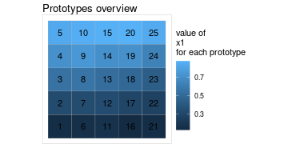

```r
par(mfrow=c(1,2))
plot(my.som, what="prototypes", type="color", var=1)
```

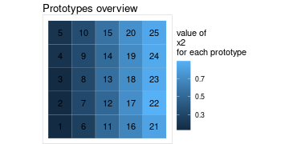

```r
plot(my.som, what="prototypes", type="color", var=2)
```

Here, the interpretation is simple enough: high values of the first variables x1 are located at the top of the map and small values at the bottom of the map. Large values of x2 are located at the right hand side of the map, whereas, small values are located at the left hand side.

The prototypes coordinates are also registered for each intermediate backup so they can be displayed on different graphics to see the evolution in the prototype organization.

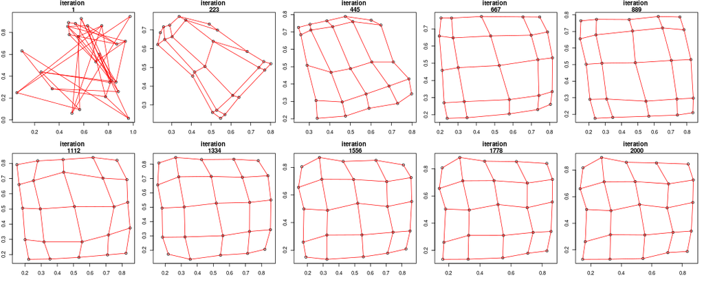

At the beginning of the algorithm, the prototypes are randomly distributed in [0,1]<sup>2</sup> and then, they organize as a regular rectangular grid in \([0,1]^2\).

## Second case study: the iris dataset

This second case study is performed on the famous (Fisher's or Anderson's) iris data set that gives the measurements in centimeters of the variables sepal length and width and petal length and width, respectively, for 50 flowers from each of 3 species of iris (setosa, versicolor, and virginica).

### Training the SOM

**NB: In the following analysis, variables are centered and scaled to unit variance, which is the default behavior of the algorithm.**

The first four variables of the data set (that are the numeric variables) are used to map each flower on the SOM grid.

```r
set.seed(255)
# run the SOM algorithm with verbose set to TRUE
iris.som <- trainSOM(x.data = iris[,1:4], dimension = c(5,5), verbose = TRUE,
                     nb.save = 5, topo = "hexagonal")
```

```
## Self-Organizing Map algorithm...
##
##   Parameters of the SOM
##
##     SOM mode                       :  online
##     SOM type                       :  numeric
##     Affectation type               :  standard
##     Grid                           :
##       Self-Organizing Map structure
##
##         Features   :
##            topology     :  hexagonal
##            x dimension  :  5
##            y dimension  :  5
##            distance type:  euclidean
##
##     Number of iterations           :  750
##     Number of intermediate backups :  5
##     Initializing prototypes method :  random
##     Data pre-processing type       :  unitvar
##     Neighbourhood type             :  gaussian
##
## 0 % done
## 10 % done
## 20 % done
## 30 % done
## 40 % done
## 50 % done
## 60 % done
## 70 % done
## 80 % done
## 90 % done
## 100 % done
```

```r
iris.som
```

```
##       Self-Organizing Map object...
##          online learning, type: numeric
##          5 x 5 grid with hexagonal topology
##          neighbourhood type: gaussian
##          distance type: euclidean
```

As the energy is registered during the intermediate backups, we can have a look at its evolution.

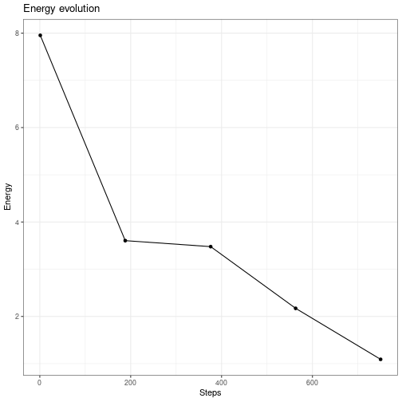

```r
plot(iris.som, what="energy")
```

### Resulting clustering

The clustering component contains the final classification of the dataset. It is a vector with length equal to the number of rows of the input dataset.

```r
iris.som$clustering
```

```
##   1   2   3   4   5   6   7   8   9  10  11  12  13  14  15  16  17  18  19  20
##   5   5   5   5   5   5   5   5   5   5   5   5   5   5   5   5   5   5   5   5
##  21  22  23  24  25  26  27  28  29  30  31  32  33  34  35  36  37  38  39  40
##   5   5   5   5   5   4   5   5   5   5   5   5   5   5   5   5   5   5   5   5
##  41  42  43  44  45  46  47  48  49  50  51  52  53  54  55  56  57  58  59  60
##   5   2   5   5   5   5   5   5   5   5  23  23  21   6  16   6  23   1  23   1
##  61  62  63  64  65  66  67  68  69  70  71  72  73  74  75  76  77  78  79  80
##   1  18   6  17   1  23  17   1  11   1  23  11  16  11  17  23  21  21  17   1
##  81  82  83  84  85  86  87  88  89  90  91  92  93  94  95  96  97  98  99 100
##   1   1   6  16  12  25  23  11  12   6   6  18   6   1   6  12   6  17   1   6
## 101 102 103 104 105 106 107 108 109 110 111 112 113 114 115 116 117 118 119 120
##  21  16  21  21  21  21   6  21  21  21  21  21  21  16  21  21  21  21  21  11
## 121 122 123 124 125 126 127 128 129 130 131 132 133 134 135 136 137 138 139 140
##  21  16  21  21  21  21  16  22  21  21  21  21  21  16  16  21  21  21  22  21
## 141 142 143 144 145 146 147 148 149 150
##  21  21  16  21  21  21  21  21  21  22
```

```r
table(iris.som$clustering)
```

```
##
##  1  2  4  5  6 11 12 16 17 18 21 22 23 25
## 11  1  1 48 11  5  3 10  5  2 41  3  8  1
```

which can also be visualized by a hitmap plot:

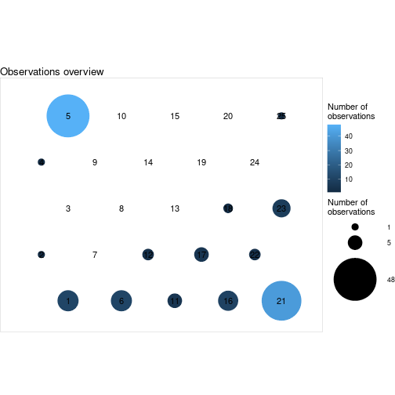

```r
plot(iris.som, what="obs", type="hitmap")
```

To assess the relevance of each explanatory variable in the definition of the clusters, the function `summary` includes an ANOVA with the predictor being the clustering, for each (numeric) input variable.

```r
summary(iris.som)
```

```
##
## Summary
##
##       Class :  somRes
##
##       Self-Organizing Map object...
##          online learning, type: numeric
##          5 x 5 grid with hexagonal topology
##          neighbourhood type: gaussian
##          distance type: euclidean
##
##       Final energy     : 1.091265
##       Topographic error: 0.1466667
##
##       ANOVA                :
##
##         Degrees of freedom :  13
##
##                    F pvalue significativity
## Sepal.Length  43.463      0             ***
## Sepal.Width   17.240      0             ***
## Petal.Length 298.228      0             ***
## Petal.Width  173.062      0             ***
```

Here, all variables have significantly different means among the different clusters and can thus be considered to be relevant for the clustering definition.

Another useful function is `predict.somRes`. This function predicts the neuron to which a new observation would be assigned. The first argument must be a `somRes` object and the second one the new observation. Let us have a try on the first observation of the iris data set:

```r
# call predict.somRes
predict(iris.som, iris[1,1:4])
```

```
## 5
## 5
```

```r
# check the result of the final clustering with the SOM algorithm
iris.som$clustering[1]
```

```
## 1
## 5
```

### Clustering interpretation

#### Graphics common to observations and prototypes

Some graphics are shared between observations and prototypes and can be used to display the prototypes' or the observations' values for the different variables in the neurons of the map. For observations, the mean values are sometimes displayed instead of the individual values.

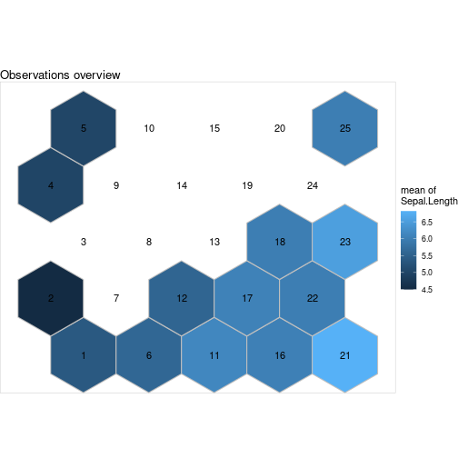

```r
par(mfrow = c(2,2))
plot(iris.som, what = "obs", type = "color", variable = 1)
```

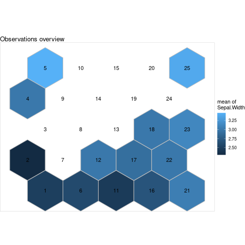

```r
plot(iris.som, what = "obs", type = "color", variable = 2)
```

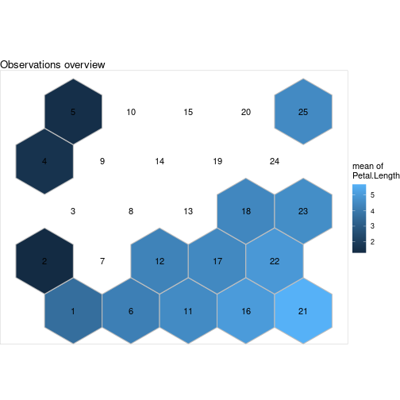

```r
plot(iris.som, what = "obs", type = "color", variable = 3)
```

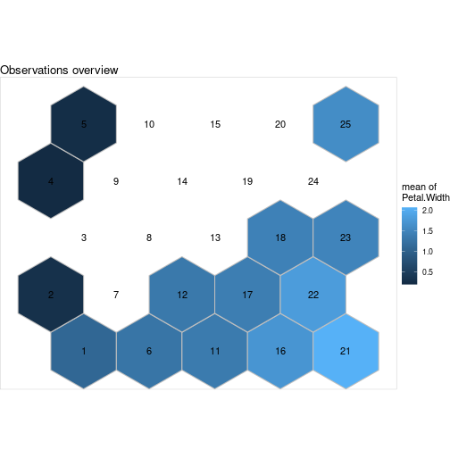

```r
plot(iris.som, what = "obs", type = "color", variable = 4)
```

Some neurons are empty (no observations affected to them): neurons 3, 7, 8, 9, 10, 13, 14, 15, 19, 20, 24. They are the illustration of a large difference between observations classified in clusters 4-5 with the rest of the observations (to some extend, the same can be said about observations in cluster 25).

#### More graphics on observations

They display either the observation distribution within the cluster for all the variables in the dataset (for `"boxplot"` and `"lines"`) or the names (row numbers by default) of the observations classified within the cluster.

#### More graphics on prototypes

Some more graphics handling prototypes have been implemented:

- `"3d"` provides the same results as `"color"` but on a 3 dimensional plot: x is the x dimension of the grid, y is the y dimension of the grid and z is the value of the prototype for the variable `variable` (by name or number in the dataset) of the corresponding neuron. For the hexagonal topology, the plot is obtained using a linear interpolation on a regular square grid.

Also, some graphics are provided to visualize the distance between prototypes on the grid:

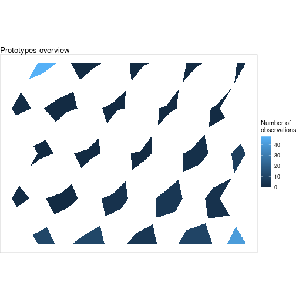

```r
plot(iris.som, what = "prototypes", type = "poly.dist", show.names = FALSE)
```

- `"poly.dist"` represents the distances between neighboring prototypes with polygons plotted for each cell of the grid. The smaller the distance between a polygon's vertex and a cell border, the closer the pair of prototypes. The colors indicates the number of observations in the neuron (white is used for empty neurons);
- `"umatrix"` fills the neurons of the grid using colors that represent the average distance between the current prototype and its neighbors;
- `"smooth.dist"` plots the mean distance between the current prototype and its neighbors with a color gradation;
- `mds` plots the number of the neuron on a map according to a Multi Dimensional Scaling (MDS) projection;
- `grid.dist` plots a point for each pair of prototypes, with x coordinates representing the distance between the prototypes in the input space, and y coordinates representing the distance between the corresponding neurons on the grid.

These graphics show that there is a big gap (large distances) between the top left corner and the rest of the map and between the top right corner and the rest of the map (which is consistent with what was already observed in the previous plots). In addition, the bottom right corner of the maps has a few neurons (21, 22, 23) that are very closed to each others.

#### Graphics showing an additional variable

##### Additional factor

The clustering can be analyzed together with an additional variable (here, the flower species) using `what = "add"`:

```r
class(iris$Species)
```

```
## [1] "factor"
```

```r
levels(iris$Species)
```

```
## [1] "setosa"     "versicolor" "virginica"
```

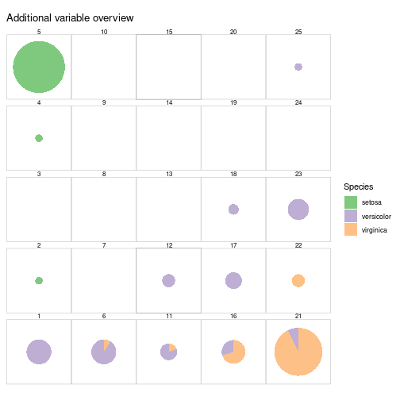

```r
plot(iris.som, what = "add", type = "pie", variable = iris$Species) +
  scale_fill_brewer(type = "qual") +
  guides(fill = guide_legend(title = "Species"))
```

This plot shows that the clustering produced by the SOM is indeed relevant to identify the three different species of iris: they are well separated on the map and almost all clusters only contain one species of iris. The Setosa species is the most distinct from the other two, isolated in the top left corner of the map.

##### Additional numerical vector

The `"color"` plot available for `"add"` is similar to the `"obs"` or `"prototypes"` cases. Here we choose the first variable of the iris data set as an additional variable to illustrate its use. We thus obtain the same plot as above (see section **Graphics common to observations and prototypes**).

##### Additional numerical matrix or data frame

The `"lines"`, `"barplot"`, `"radar"` and `"boxplot"` plots available for `"add"` are similar to the `"obs"` or `"prototypes"` cases.

##### Additional non-numerical vector

`"names"` is similar to the `"names"` case implemented for `"obs"`. Here we choose to give the argument `variable` the row names of the iris data set: so we obtain the same plot as above (see **More graphics on observations**).

which gives exactly the same plot as before for type `"words"` with the contingency matrix corresponding to the variable `iris$Species`.

### Analyze the projection quality

```r
quality(iris.som)
```

```
## $topographic
## [1] 0.1466667
##
## $quantization
## [1] 1.22527
```

By default, the quality function calculates both quantization and topographic errors. It is also possible to specify which one you want using the argument `quality.type`.

The quantization error is an unbounded positive number. The closer it is to 0, the better the projection quality.

### Building super classes from the resulting SOM

In the SOM algorithm, the number of clusters is necessarily close to the number of neurons on the grid (not necessarily equal as some neurons may have no observations assigned to them). This - quite large - number may not suit the original data for a clustering purpose.

A usual way to address clustering with SOM is to perform a hierarchical clustering on the prototypes. This clustering is directly available in the package `SOMbrero` using the function `superClass`. To do so, you can first have a quick overview to decide on the number of super clusters which suits your data.

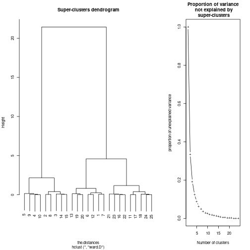

```r
plot(superClass(iris.som))
```

By default, the function plots both a dendrogram and the evolution of the percentage of explained variance. Here, 3 super clusters seem to be the best choice. The output of `superClass` is a `somSC` class object. Basic functions have been defined for this class:

```r
my.sc <- superClass(iris.som, k = 3)
summary(my.sc)
```

```
##
##    SOM Super Classes
##      Initial number of clusters :  25
##      Number of super clusters   :  3
##
##
##   Frequency table
## 1 2 3
## 7 9 9
##
##   Clustering
##  1  2  3  4  5  6  7  8  9 10 11 12 13 14 15 16 17 18 19 20 21 22 23 24 25
##  1  2  2  2  2  1  1  2  2  2  3  1  1  2  2  3  3  3  1  1  3  3  3  3  3
##
##
##   ANOVA
##
##         Degrees of freedom :  2
##
##                    F pvalue significativity
## Sepal.Length 178.319      0             ***
## Sepal.Width   60.416      0             ***
## Petal.Length 847.100      0             ***
## Petal.Width  505.974      0             ***
```

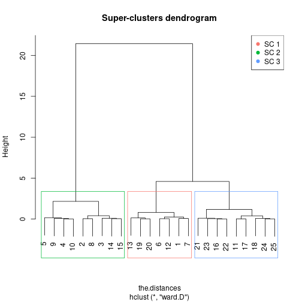

```r
plot(my.sc, plot.var = FALSE)
```

Like `plot.somRes`, the function `plot.somSC` has an argument `type` which offers many different plots and can thus be combined with most of the graphics produced by `plot.somSC`:

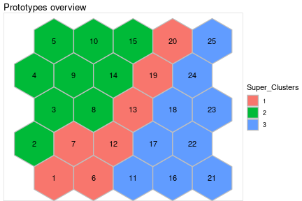

```r
plot(my.sc, type = "grid")
```

Case `"grid"` fills the grid with colors according to the super clustering (and can provide a legend). Case `"dendro3d"` plots a 3d dendrogram.

And some others identify the super clusters with titles:

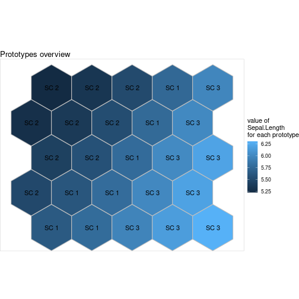

```r
plot(my.sc, what = "prototypes", type = "color", variable = "Sepal.Length")
```

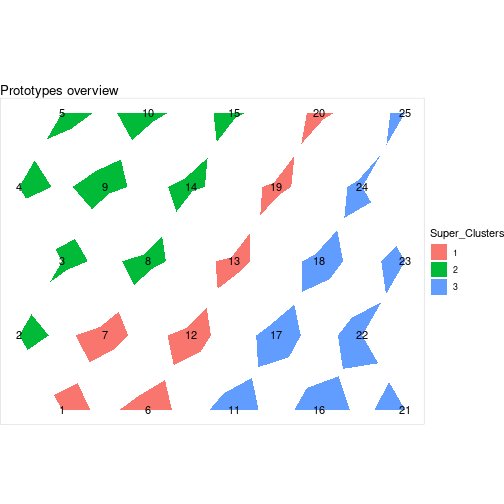

```r
plot(my.sc, what = "prototypes", type = "poly.dist")
```

Super cluster number 2 is located at the top left hand corner of the map and associated with the Setosa species. SC 3 is in the opposite corner and associated mainly with Virginica whereas SC 1 is in the diagonal between these two corners and associated with Versicolor.